# To B(MW) or not to BMW?: Unit 2 Takehome

Bryan Li

3/2/2019

#### 1)

Can highway mileage be predicted from city mileage better for BMW cars or for General Motor cars?

#### 2)

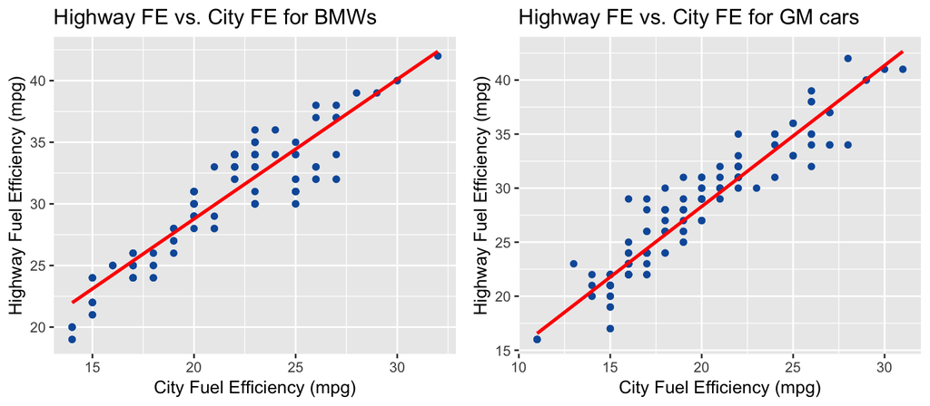

The graphs appear to have a relatively high correlation. Therefore, there is a high association between highway FE and city FE, which means the question is valid. Additionally, both variables compared are quantitative and the models look somewhat linear with few outliers, so the linear model used will work fine.

#### 3)

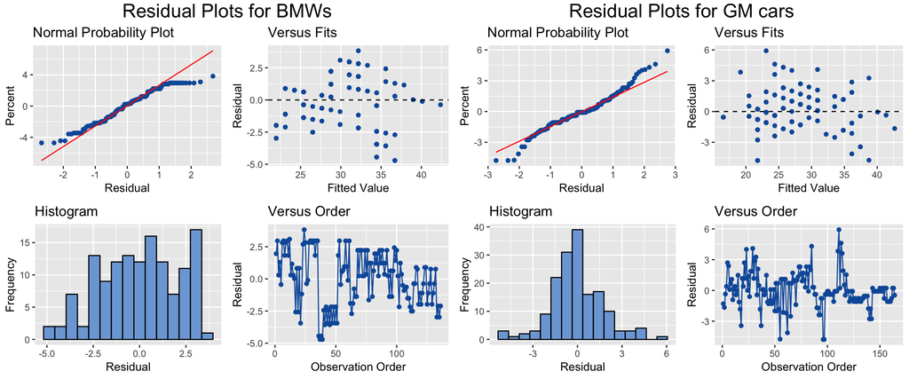

#### 5)

The LSRL for BMWs is $[Highway\text{ }FE] = 1.133 * [City\text{ }FE] + 6.109$.

The LSRL for GM cars is $[Highway\text{ }FE] = 1.305 * [City\text{ }FE] + 2.196$.

#### 6)

The value of the coefficient (a) of the LSRL for BMWs, 1.133, indicates that for every increase in city fuel efficiency there is an predicted increase in highway fuel efficiency of 1.133. The y-intercept (b) of the LSRL for GM cars, 2.196, indicates that when a car has 0 miles per gallon for city fuel efficiency the predicted highway fuel efficiency is 2.196. This is somewhat useless information however as there is no data near 0 thus making it inaccurate there and because a fuel efficiency of 0 mpg is not seen in functioning cars.

#### 7)

The $\sum{(y - \overline{y})^2}$ for BMWs is $3274$ and $5461.774$ for GM cars.

#### 8)

The $\sum{(y - \widehat{y})^2}$ for BMWs is $586.933$ and $475.126$ for GM cars.

#### 9)

The r-squared for BMWs is $0.821$ and $0.913$ for GM cars.

#### 10)

Question 7 gives the total squared error (total variance) of the datasets. This is the combined squared values of the difference between each highway FE value and the mean of the highway FE as a whole. Question 8 gives the total squared residuals of the datasets compared to the line of fit. Question 9 gives the coefficient of determination, which is equal to $1 - [total\text{ }residuals^2]/[total\text{ }variance^2]$ (where residuals is the answer to question 8 and variance is the answer to question 7).

#### 11)

Therefore, highway mileage can be better predicted from city mileage for GM cars compared to BMWs.